# Porblem 4

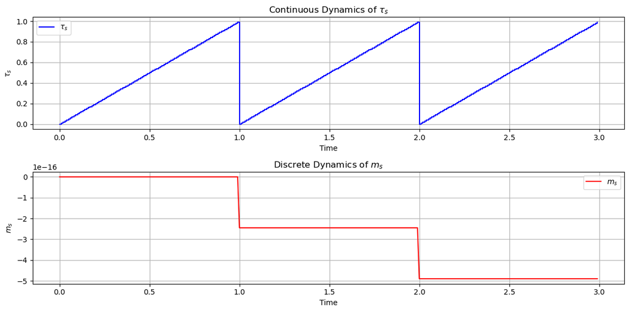

```python
import numpy as np
import matplotlib.pyplot as plt

# Parameters
T_s_star = 1
v_s = lambda t: np.sin(2 * np.pi * t)

# Time parameters
t_end = 3  # End time for the simulation
dt = 0.01  # Time step
times = np.arange(0, t_end, dt)

# Initialize states
tau_s = np.zeros_like(times)
m_s = np.zeros_like(times)
current_tau = 0
current_m = 0

# Simulation loop
for i, t in enumerate(times):
    if current_tau >= T_s_star:
        current_tau = 0
        current_m = v_s(t)
    tau_s[i] = current_tau
    m_s[i] = current_m
    current_tau += dt

# Plot results
plt.figure(figsize=(12, 6))

# Plot τ_s
plt.subplot(2, 1, 1)
plt.step(times, tau_s, where='post', label=r'$\tau_s$', color='blue')
plt.xlabel('Time')
plt.ylabel(r'$\tau_s$')
plt.title(r'Continuous Dynamics of $\tau_s$')
plt.grid(True)
plt.legend()

# Plot m_s
plt.subplot(2, 1, 2)
plt.plot(times, m_s, label=r'$m_s$', color='red')
plt.xlabel('Time')
plt.ylabel(r'$m_s$')
plt.title(r'Discrete Dynamics of $m_s$')
plt.grid(True)
plt.legend()

plt.tight_layout()
plt.show()
```

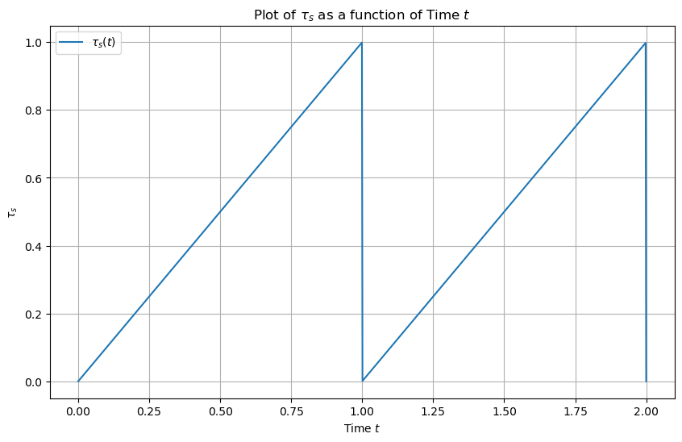

```python
import numpy as np
import matplotlib.pyplot as plt

# Parameters
T_s_star = 1
v_s = lambda t: np.sin(2 * np.pi * t)

# Time array
t = np.linspace(0, 2 * T_s_star, 1000)  # Time range

# Initialize tau_s and m_s
tau_s = np.zeros_like(t)

# Fill tau_s based on the system dynamics
for i, time in enumerate(t):
    # Determine the current cycle
    j = int(time // T_s_star)
    t_in_cycle = time % T_s_star

    if t_in_cycle <= T_s_star:
        tau_s[i] = t_in_cycle
    else:
        tau_s[i] = 0  # Reset condition

# Plotting
plt.figure(figsize=(10, 6))
plt.plot(t, tau_s, label='$\\tau_s(t)$')
plt.xlabel('Time $t$')
plt.ylabel('$\\tau_s$')
plt.title('Plot of $\\tau_s$ as a function of Time $t$')
plt.grid(True)
plt.legend()
plt.show()
```

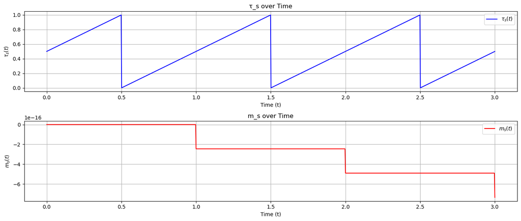

```python
import numpy as np
import matplotlib.pyplot as plt

# Parameters
Ts_star = 1
def vs(t):
    return np.sin(2 * np.pi * t)

# Time vectors
time = np.linspace(0, 3, 1000)  # Extended time for better visualization
tau_start = Ts_star / 2  # Starting point for tau_s

# Initialize arrays
tau_s = np.zeros_like(time)
m_s = np.zeros_like(time)

# Compute tau_s and m_s
for i, t in enumerate(time):
    # Determine current cycle index (j) and time within the cycle
    j = int(np.floor(t / Ts_star))
    t_mod = t % Ts_star

    # Compute tau_s
    if t == 0:
        tau_s[i] = tau_start
    else:
        tau_s[i] = (tau_start + t_mod) % Ts_star

    # Compute m_s based on reset times
    if t_mod == 0 and t != 0:  # Reset occurs at each Ts_star interval
        m_s[i] = vs(t)
    else:
        m_s[i] = m_s[i-1] if i > 0 else 0

# Plotting
plt.figure(figsize=(14, 6))

# Plot tau_s
plt.subplot(2, 1, 1)
plt.plot(time, tau_s, label=r'$\tau_s(t)$', color='blue')
plt.title('τ_s over Time')
plt.xlabel('Time (t)')
plt.ylabel(r'$\tau_s(t)$')
plt.grid(True)
plt.legend()

# Plot m_s
plt.subplot(2, 1, 2)
plt.plot(time, m_s, label=r'$m_s(t)$', color='red')
plt.title('m_s over Time')
plt.xlabel('Time (t)')
plt.ylabel(r'$m_s(t)$')
plt.grid(True)
plt.legend()

plt.tight_layout()
plt.show()
```

To model the series interconnection between an **Analog-to-Digital Converter (ADC)** and a **Finite State Machine (FSM)** using hybrid systems, we need to define the hybrid system components: functions $ F $ and $ G $, and sets $ C $ and $ D $.

### Hybrid System Components

1. **State Variables**:
   - Let $\tau_s$ represent the time in the ADC.
   - Let $m_s$ represent the sampled value from the ADC.
   - Let $x_{fsm}$ represent the state of the FSM.
   - Let $u$ be the input to the FSM, which is the output of the ADC.
2. **Continuous Dynamics**:
   - **ADC**:
     - The ADC has continuous dynamics described by: $ \dot{\tau}_s = 1 $ $ \dot{m}_s = 0 $
     - When $\tau_s \geq T_s^*$, reset conditions apply: $ \tau_s^+ = 0 $ $ m_s^+ = v_s $
   - **FSM**:
     - The FSM is a discrete system with states changing based on its transition function.
3. **Hybrid System Representation**:

   **Hybrid Equations/Inclusions**:
   - **Continuous Dynamics** (for ADC):
     - $ \dot{\tau}_s = 1 $
     - $ \dot{m}_s = 0 $
   - **Jump Conditions** (for ADC):
     - If $\tau_s \geq T_s^*$, then: $ \tau_s^+ = 0 $ $ m_s^+ = v_s $
   - **State Evolution in FSM**:
     - The FSM evolves based on the input $ m_s $ from the ADC and its transition function.

   **Functions and Sets**:
   - **Functions $ F $ and $ G $**:
     - **Function $ F $** describes the continuous dynamics: $ F(x) = \begin{bmatrix} \dot{\tau}_s \\ \dot{m}_s \end{bmatrix} = \begin{bmatrix} 1 \\ 0 \end{bmatrix} $
     - **Function $ G $** describes the jump map: $ G(x) = \begin{bmatrix} \tau_s^+ \\ m_s^+ \end{bmatrix} = \begin{bmatrix} 0 \\ v_s \end{bmatrix} $
   - **Sets $ C $ and $ D $**:
     - **Set $ C $** represents the continuous domain where the dynamics are defined: $ C = \{ (\tau_s, m_s) \mid 0 \leq \tau_s < T_s^* \} $
     - **Set $ D $** represents the jump set, where the state transitions occur: $ D = \{ (\tau_s, m_s) \mid \tau_s \geq T_s^* \} $

### Full Hybrid System Model

Combining these components, the hybrid system can be described as follows:

1. **Continuous Dynamics**: $ \dot{x} = F(x) = \begin{bmatrix} \dot{\tau}_s \\ \dot{m}_s \end{bmatrix} = \begin{bmatrix} 1 \\ 0 \end{bmatrix} \text{ for } (\tau_s, m_s) \in C $
2. **Jump Map**: $ x^+ = G(x) = \begin{bmatrix} \tau_s^+ \\ m_s^+ \end{bmatrix} = \begin{bmatrix} 0 \\ v_s \end{bmatrix} \text{ for } (\tau_s, m_s) \in D $
3. **Continuous Set**: $ C = \{ (\tau_s, m_s) \mid 0 \leq \tau_s < T_s^* \} $
4. **Jump Set**: $ D = \{ (\tau_s, m_s) \mid \tau_s \geq T_s^* \} $

### Notes

- **ADC Dynamics**: Continuously evolves by incrementing $\tau_s$ and holding $m_s$.
- **FSM Dynamics**: Discretely updates based on inputs from the ADC.

This model describes how the ADC's output is fed into the FSM, with transitions occurring based on the ADC's reset conditions.